# l4p2_regressao_romantica

devjaynemorais

8 de julho de 2019

Jayne Morais Mestrado 2019.1 (UFCG) - FPCC2

```r
dados = read_csv("speed-dating/speed-dating2.csv")
```

[output not shown]

```r
dados = dados %>% mutate(match = ifelse(dec == "yes", 1, 0))
```

Análise exploratória dos dados:

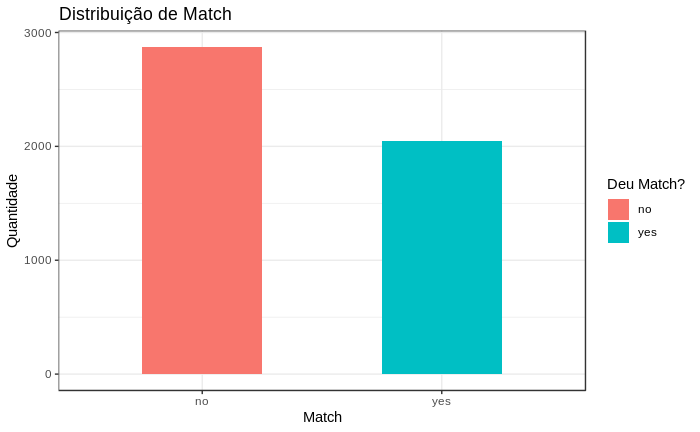

```r
dados  %>%
  ggplot(aes(x = dec, fill = dec)) +
    geom_bar(width=.5) +
    labs(
        title = "Distribuição de Match",
        y = "Quantidade",
        x = "Match"
      ) +
  guides(fill=guide_legend("Deu Match?"))
```

É possível observar que há uma quantidade bem menor de match correspondido do que não correspondido.

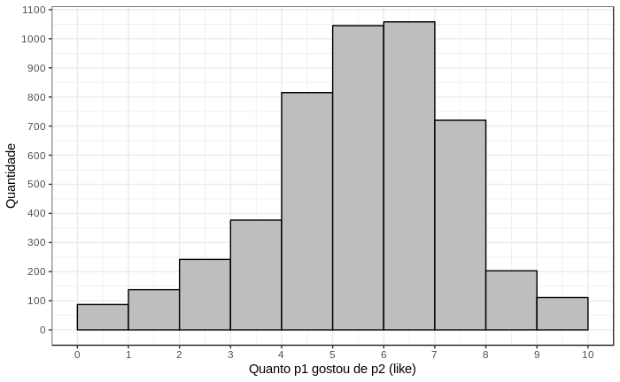

```r
dados %>%
  #na.omit(samerace) %>%
  ggplot(aes(x = like)) +
  geom_histogram(color = "black",
                 fill = "grey",
                 breaks=seq(0, 10, by = 1)) +
  scale_x_continuous(breaks=seq(0, 10, by = 1)) +
  scale_y_continuous(breaks=seq(0, 10000, by = 100)) +
  labs(x= "Quanto p1 gostou de p2 (like)",
       y = "Quantidade")
```

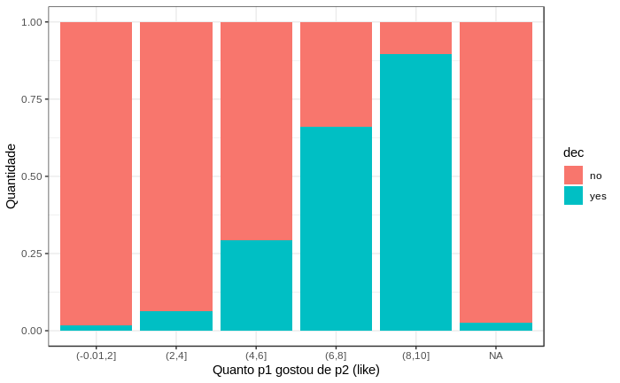

```r
dados %>%
  mutate(like = cut(like, 5)) %>%
  ggplot(aes(x = like, fill = dec)) +
  geom_bar(position = "fill") +
  labs(x= "Quanto p1 gostou de p2 (like)",
       y = "Quantidade")
```

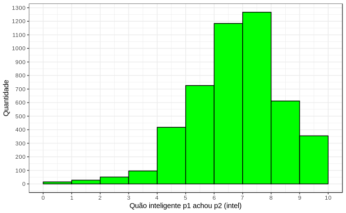

```r
dados %>%
  #na.omit(samerace) %>%
  ggplot(aes(x = intel)) +
  geom_histogram(color = "black",
                 fill = "green",
                 breaks=seq(0, 10, by = 1)) +
  scale_x_continuous(breaks=seq(0, 10, by = 1)) +
  scale_y_continuous(breaks=seq(0, 10000, by = 100)) +
  labs(x= "Quão inteligente p1 achou p2 (intel)",
       y = "Quantidade")
```

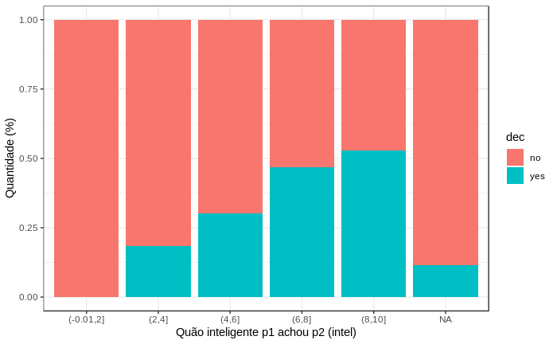

```r
dados %>%
  mutate(intel = cut(intel, 5)) %>%
  ggplot(aes(x = intel, fill = dec)) +
  geom_bar(position = "fill") +
  labs(x= "Quão inteligente p1 achou p2 (intel)",
       y = "Quantidade (%)")
```

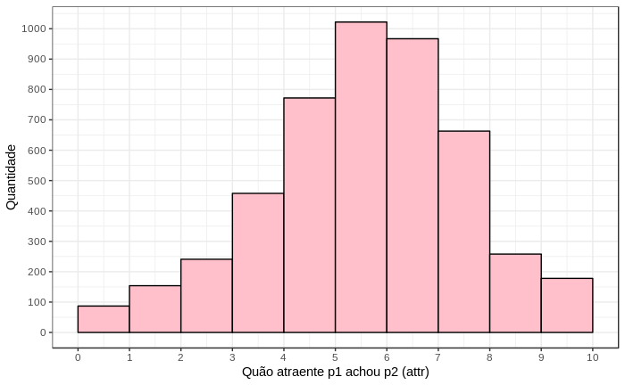

```r
dados %>%
  #na.omit(samerace) %>%
  ggplot(aes(x = attr)) +
  geom_histogram(color = "black",
                 fill = "pink",
                 breaks=seq(0, 10, by = 1)) +
  scale_x_continuous(breaks=seq(0, 10, by = 1)) +
  scale_y_continuous(breaks=seq(0, 10000, by = 100)) +
  labs(x= "Quão atraente p1 achou p2 (attr)",
       y = "Quantidade")
```

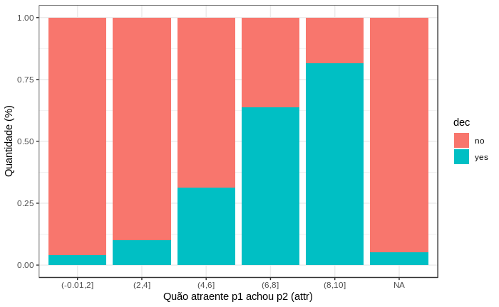

```r
dados %>%
  mutate(attr = cut(attr, 5)) %>%
  ggplot(aes(x = attr, fill = dec)) +
  geom_bar(position = "fill") +
  labs(x= "Quão atraente p1 achou p2 (attr)",
       y = "Quantidade (%)")
```

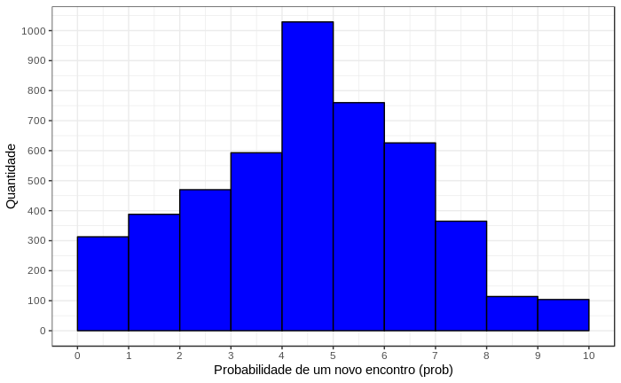

```r
#dados %>%
  #na.omit(samerace) %>%
 # ggplot(aes(x = prob, fill = dec)) +
  #geom_histogram(
         #        breaks=seq(0, 10, by = 1)) +
  #scale_x_continuous(breaks=seq(0, 10, by = 1)) +
  #scale_y_continuous(breaks=seq(0, 10000, by = 100)) +
  #labs(x= "Quão atraente p1 achou p2 (prob)",
      # y = "Quantidade")
dados %>%
  #na.omit(samerace) %>%
  ggplot(aes(x = prob)) +
  geom_histogram(color = "black",
                 fill = "blue",
                 breaks=seq(0, 10, by = 1)) +
  scale_x_continuous(breaks=seq(0, 10, by = 1)) +
  scale_y_continuous(breaks=seq(0, 10000, by = 100)) +
  labs(x= "Probabilidade de um novo encontro (prob)",
       y = "Quantidade")
```

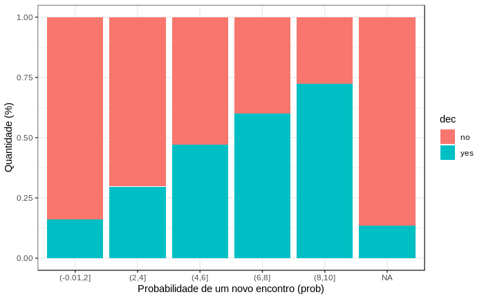

```r
dados %>%
  mutate(prob = cut(prob, 5)) %>%
  ggplot(aes(x = prob, fill = dec)) +
  geom_bar(position = "fill") +
  labs(x= "Probabilidade de um novo encontro (prob)",
       y = "Quantidade (%)")
```

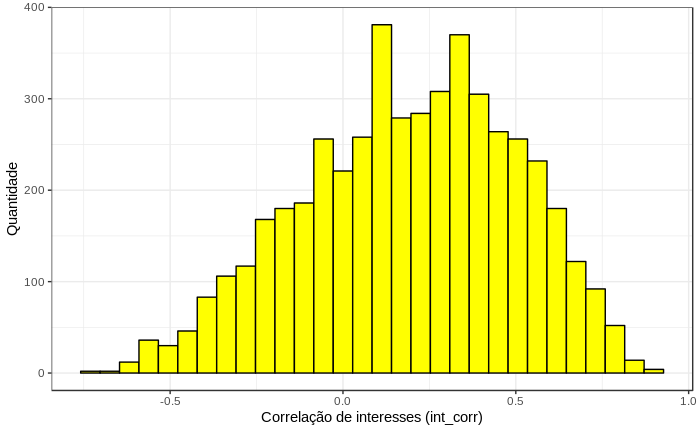

```r
dados %>%
  #na.omit(prob) %>%
  ggplot(aes(x = int_corr)) +
  geom_histogram(color = "black",
                 fill = "yellow") +
  #scale_x_continuous(breaks=seq(0, 10, by = 1)) +
  scale_y_continuous(breaks=seq(0, 10000, by = 100)) +
  labs(x= "Correlação de interesses (int_corr)",
       y = "Quantidade")
```

[figure not shown]

```r
dados %>%
  mutate(prob = cut(prob, 5)) %>%
  ggplot(aes(x = prob, fill = dec)) +
  geom_bar(position = "fill") +
  labs(x= "Correlação de interesses (int_corr)",
       y = "Quantidade (%)")
```

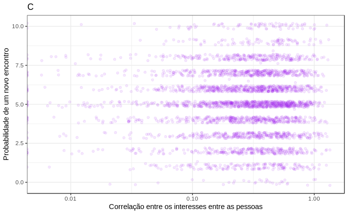

```r
dados  %>%
  ggplot(aes(y=prob, x=int_corr)) +
  geom_point(alpha = 0.1, position = position_jitter(width = 0.25), color="purple") +
  labs(
    title="C",
    x= "Correlação entre os interesses entre as pessoas",
    y= "Probabilidade de um novo encontro"
  ) +
  scale_x_log10()
```

Para esta análise serão escolhidas as seguintes variáveis:

`prob` : que probabiliade p1 acha que p2 tem de querer se encontrar novamente com p- (escala 1-10) `int_corr` : correlação entre os interesses de p1 e p2 `like` : no geral, quanto p1 gostou de p2? `intel` : quão inteligente p1 achou p2 `attr` : quão atraente p1 achou p2

```r
#dados = dados %>% augment(type.predict = "response")
bm <- glm(match ~ int_corr + prob + like + intel + attr,
      data = dados,
      family = "binomial")
tidy(bm, conf.int = TRUE)
```

| term | estimate | std.error | statistic | p.value | conf.low | conf.high |
| --- | --- | --- | --- | --- | --- | --- |
| (Intercept) | -6.51308322 | 0.25487525 | -25.5540040 | 4.955911e-144 | -7.0195471 | -6.0202743 |
| int_corr | 0.03732472 | 0.12118871 | 0.3079885 | 7.580911e-01 | -0.2001491 | 0.2750162 |
| prob | 0.18171052 | 0.02022508 | 8.9844159 | 2.601123e-19 | 0.1422017 | 0.2215039 |
| like | 0.65157693 | 0.03636414 | 17.9181153 | 8.516485e-72 | 0.5810528 | 0.7236335 |
| intel | -0.20337421 | 0.03028493 | -6.7153597 | 1.876029e-11 | -0.2630200 | -0.1442722 |
| attr | 0.42613033 | 0.02799843 | 15.2197941 | 2.613524e-52 | 0.3716347 | 0.4814180 |

```r
tidy(bm, conf.int = TRUE, exponentiate = TRUE)
```

| term | estimate | std.error | statistic | p.value | conf.low | conf.high |
| --- | --- | --- | --- | --- | --- | --- |
| (Intercept) | 0.001483897 | 0.25487525 | -25.5540040 | 4.955911e-144 | 0.0008942304 | 0.002429003 |
| int_corr | 1.038030037 | 0.12118871 | 0.3079885 | 7.580911e-01 | 0.8186087055 | 1.316552050 |
| prob | 1.199266979 | 0.02022508 | 8.9844159 | 2.601123e-19 | 1.1528091137 | 1.247952139 |
| like | 1.918563877 | 0.03636414 | 17.9181153 | 8.516485e-72 | 1.7879198150 | 2.061911658 |
| intel | 0.815972836 | 0.03028493 | -6.7153597 | 1.876029e-11 | 0.7687265156 | 0.865652124 |
| attr | 1.531320338 | 0.02799843 | 15.2197941 | 2.613524e-52 | 1.4501031152 | 1.618367652 |

```r
glance(bm)
```

| null.deviance | df.null | logLik | AIC | BIC | deviance | df.residual |
| --- | --- | --- | --- | --- | --- | --- |
| 6331.339 | 4637 | -2208.293 | 4428.587 | 4467.239 | 4416.587 | 4632 |

```r
pR2(bm)
```

```
          llh       llhNull            G2      McFadden          r2ML          r2CU
-2208.2932637 -3338.8632511  2261.1399748     0.3386093     0.3858553     0.5056940
```

Com 95% de confiança.

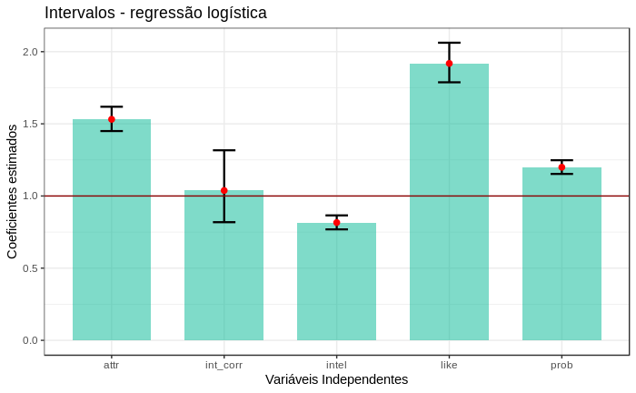

```r
tidy(bm, conf.int = TRUE, conf.level = 0.95, exponentiate = TRUE) %>%
  filter(term != "(Intercept)") %>%
  ggplot(aes(term, estimate, ymin = conf.low, ymax = conf.high)) +
  geom_bar(stat = "identity", position = position_dodge(0.8), fill="#00b894", alpha=0.5, width=.7) +
  geom_errorbar(size = 0.8, width= 0.2) +
  geom_point(color = "red", size = 2) +
  geom_hline(yintercept = 1, colour = "darkred") +
  labs(x = "Variáveis Independentes",
       title = "Intervalos - regressão logística",
       y = expression("Coeficientes estimados"))
```

# Que fatores nos dados têm efeito relevante na chance do casal ter um match? Descreva se os efeitos são positivos ou negativos e sua magnitude.

### Conclusão

Na amostra de dados analisada foi utilizada regressão múltipla logística foi utilizada para analisar se a relação entre as variáveis `prob` (a probabiliade p1 acha que p2 tem de querer se encontrar novamente), `int_corr` (a correlação entre os interesses de p1 e p2), `like` (no geral, quanto p1 gostou de p2), `intel` (quão inteligente p1 achou p2), `attr` (quão atraente p1 achou p2) possuem uma associação com o odds de haver match entre dois participantes do encontro.

Os resultados da regressão indicam que um modelo com os 5 preditores no formato $\frac{p(y)}{1-p(y)} = 0,0014 + 1,03^{int\_corr} + 1,19^{prob} + 1,91^{like} + 0,81^{intel} + 1,53^{attr}$ explicam 33,86% da variância da variável de resposta medido pelo McFadden, correspondendo a $\frac{1}{3}$.

Após análise dos resultados obtidos para os valores das estimativas associadas a cada variável independente, implicam que:

**Considerações:**

- A variável $int\_corr$, medida como a correlação entre os interesses de p1 e p2, possui uma relação muito pequena e positiva (ou talvez nem possuir, pelo fato do intervalo de confiança incluir o 0), porém não se pode confirmar ou descartar um efeito importante sobre esta última, com o erro b = [0,81; 1.31], IC com 95%;
- A variável $prob$, medida como a probabiliade p1 acha que p2 tem de querer se encontrar novamente, tem uma relação positiva e relevante com o erro b = [1,15; 1,24], IC com 95%;
- A variável $like$, medida como quanto p1 gostou de p2, possui uma relação muito relevante e positivo com o erro b = [1,78; 2,06], IC com 95%;
- A variável $intel$, medida como quão inteligente p1 achou p2, possui uma relação negativa e pouco relevante com o erro b = [0,76; 0,86], IC com 95%.
- A variável $attr$, medida como quão atraente p1 achou p2, possui uma relação positiva e relevante com o erro b = [1,45; 1,61], IC com 95%.

O modelo só explica aproximadamente $ (33,86%) da variância do modelo pelo MC Fadden, e consequentemente, é importante analisar o impacto de outras variáveis para medir o odds de dar match entre os participantes.

Portanto, na prática, é possível observar que os de acordo com os dados coletados e disponibilizados por professores da Columbia Business School gerados pelo experimento envolvendo 310 jovens americanos, apontam que dentre as variáveis as variáveis `prob` (a probabiliade p1 acha que p2 tem de querer se encontrar novamente), `int_corr` (a correlação entre os interesses de p1 e p2), `like` (no geral, quanto p1 gostou de p2), `intel` (quão inteligente p1 achou p2), `attr` (quão atraente p1 achou p2): a variável `like` aparenta ser o quesito mais relevante entre candidatos, ou seja, o que produz mais efeito sobre o odds de p1 dar match entre p1 e p2. Enquanto que as variáveis `atrr` e `prob` têm um pequeno efeito positivo e a variável `intel` possui um efeito pequeno e negativo. Já em relação a variável `int_corr` (a correlação entre os interesses de p1 e p2) aparenta ter um efeito muito pequeno e positivo, porém não se pode confirmar ou descartar um efeito importante sobre esta última.